# DataViz Makeover 1

Add in reference lines from year 2011 to 2020. Set value to be constant, no label, dotted line with grey color.

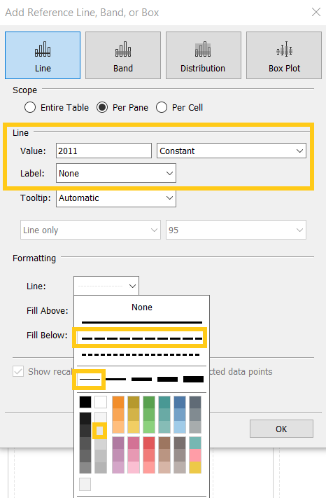

31

Right click y-axis, and select ‘Edit Axis’. Under scale, change the numbers to be integer with no decimal points and suffix with %. Double click y-axis and change the y-axis title to ’Labor Force Participation Rate (%).

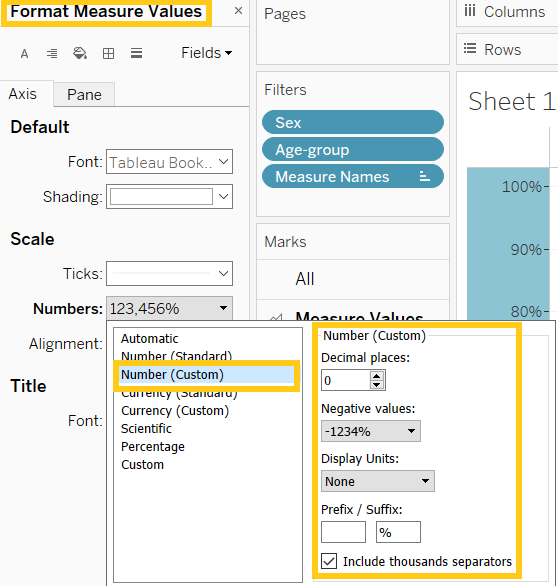

32

Bold the age-group, Y-axis and X-axis values. Add a title and subtitle to the chart.

[figure not shown]

33

Add annotation to points whereby there are interesting insights.

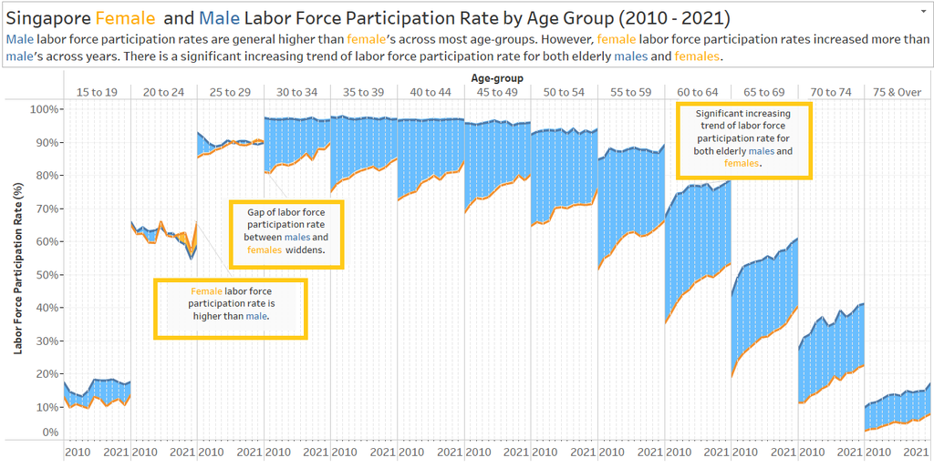

34

Show caption to add in notes and data source.

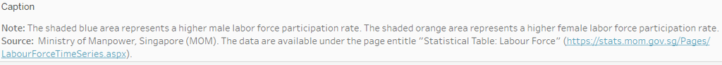

35

Save to Tableau Public.

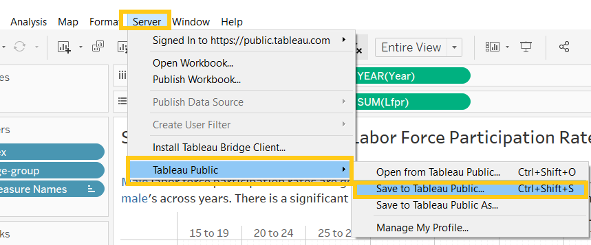

# 5. Major Observations

1. **Male labor force participation rate is higher than female.** Except for age group of 20 to 24, male labor force participation rate is in general higher than female labor force. For the age group of 20 to 24, female labor force participation rate has been higher than male labor force since 2018. Big increase of female labor force participation rate for the early 20’s is observed from year 2020 to 2021.
2. **Female labor force participation rate has been increasing faster than male since 2010.** Male labor force participation rate between age 25 to 59 has been relatively stable, compared to the increasing trend of female labor force participation rate. The gap of labor force participation rate between male and female has been shrinking since 2010.
3. **The elderly labor force participation rate for both male and female has been increasing.** This observation is for people who are older than 60.
4. **The highest male labor force participation rate falls in the 30s groups. The highest female labor force participation rate falls in the late 20s.** This could be because of women’s commitments to family after marriage.
5. **Sharp drop of labor force participation rate for the early 20s happened in 2020.** This could be of the negative impact of the Covid-19 on the employment rate for the graduates.